# DT and RF

### StatQuest: Decision Trees

[Link](https://www.youtube.com/watch?v=7VeUPuFGJHk)

A DT asks a question and classifies based on the answer

[figure not shown]

Note: A classification can be categories or numeric

In the 2nd case we are using mouse wtto predict mouse size

More complex DT:

[figure not shown]

It combines numeric data:

[figure not shown]

With Yes/No data:

[figure not shown]

Notice that cut-off for Resting heart rate need not be same on both sides

[figure not shown]

Also order of questions need not be same on both sides

The final classifications may be repeated

U start at top and go down till u get to a pt where u cant go further

Thats how a sample is classified

#### Raw table of data to DT:

We want to create a tree that uses **chest pain, good blood circulation, blocked artery status** to predict **heart disease(y/n)**

We want to decide which of **chest pain, good blood circulation, blocked artery status** should be root node

[figure not shown]

We start off by exploring how well Chest pain classifies heart disease and build a tree as shown below:

[figure not shown]

We build similar trees for Good Blood Circulation and blocked Artery

[figure not shown]

As shown above we dont kno the BA status for this patient. We skip it but there are other alternatives

As there are missing values for a feature the total number of patients in each tree is diff

[figure not shown]

**because none of the leaf nodes are 100% YES Heart disease or 100% NO they all are considered as "impure"**

To determine which separation is best we need a way to measure and compare impurity

#### Gini method to measure impurity

Gini impurity (GI) is calculated for each leaf node as shown below:

[figure not shown]

Similarly we calculate GI for right leaf node

The leaf nodes do not reppresent same number of patients

Thus total GI for using Chest pain as root node is the weighted avg of GI of the 2 nodes:

[figure not shown]

Similarly we calculate GI for all 3 possible root nodes

[figure not shown]

Good blood circulation has lowest impurity and it separates the people with or without heart disease the best

So first node (root) = GBC

After the split we get 2 leaf nodes

Left: (37 y, 127 n)

Right: (100 y, 33 n)

Now we need to figure out how to separate (and if we should separate further) these patients in the Left and Right

**Lets start with left:**

These are the patients with GBC == true

Just like before we separate these patients based on CP and calculate GI as before

We do same for Blocked Artery

GI for BA = 2.9

This is less than GI for CP and also less than GI for GBC

[figure not shown]

Thus we use BA in the left part

Resulting tree:

[figure not shown]

Now we will use CP to try and separate the L->L node(24/25)

These are the patients with GBC = true and BA = true

CP does a good job in separating the patients:

[figure not shown]

Now we look at node in Root->L->R (13/102)

Lets try and use CP to divide these 115 patients

Note : **Vast majority (89%) of patients in this node dont have heart disease**

[figure not shown]

After separating we get a higher GI than before separating

So we make this node a leaf node

[figure not shown]

We have built the entire LHS of the tree

[figure not shown]

For RHS we follow same steps:

1. Calculate all GI scores
2. If node otself has lowest score, then there is no point in separating and the node becomes a leaf node
3. If separating the data results in an improvement, pick the separation with the lowest impurity value

Complete tree:

[figure not shown]

#### Numeric data in DT:

Imagine if our features were numeric not just Y/N:

[figure not shown]

1. Sort patients by wt (lowest to highest)

[figure not shown]

1. Calculate avg wts for all adjacent patients
2. Calculate GI for each avg wt

[figure not shown]

In the above diag GI is calculated for wt < 167.5

1. The lowest GI occurs when wt < 205 (GI=0.27)

[figure not shown]

So this is the cutoff that we will use when we compare wt to CP or BA

#### DT with ranked data and multiple choice data

Ranked data is similar to numeric data, except that now we calculate impurity scores for **all possiblle ranks**

So if rank is from 1 to 4 (4 being best), we calculate impurity scores as:

- rank <= 1
- rank <= 2
- rank <= 3

We dont need <=4 as it includes everyone

When there are multiple choices like color choices - B, R or G we calculate GI for each one as well as each possible combination

- B
- G
- R
- B or G
- B or R
- G or R

We dont need to calculate for B or R or G as it includes everyone

### StatQuest: Random Forests Part 1 - Building, Using and Evaluating

[Link](https://www.youtube.com/watch?v=J4Wdy0Wc_xQ&t=143s)

DTs are easy to build, use and interpret

But in practice, theyare not that awesome

> Trees have one aspect that prevents them from being the ideal tool for predictive learning, namely **inaccuracy**

**They work great with the data used to create them but are not flexible when it comes to classifying new samples**

RF combines simplicity of DTs with flexibility resulting in a vast improvement in accuracy

#### Step 1 : Create a "bootstrapped" dataset

[figure not shown]

Say these 4 samples are entire dataset

To create a bootstrapped dataset that is same size as original we randomly select samples from original dataset

**We are allowed to pick the same sample more than once**

Say first sample in original dataset = S1

We create bootstrap dataset as: **S2, S1, S4, S4**

[figure not shown]

#### Step 2: Create a DT using Bootstrapped dataset but only use a random subset of vars (columns) at each step

In this example we will consider 2 vars at each step

Thus instead of considering all 4 vars (CP, GBC, BA, Wt) to figure out how to split the root node we randomly select 2 : GBC, BA

Say GBC did the best job at separating the samples

We used GBC, we grey it out, so that we can focus on rem vars

[figure not shown]

Now we have to figure out how to select vars for circled node:

[figure not shown]

Just like for the root we randomly select 2 vars from (CP, BA, wt)

We select CP and wt

Thus we build the tree by:

1. using the bootstrapped dataset
2. considering a random subset of vars at each step

This is done for a single tree

Now we make a new bootstrapped dataset and build tree considering a random subset of vars at each step

Ideally we do this 100s of times

considering a random subset of vars at each step

[figure not shown]

Because of the randomness associated with creating the bootsrapped dataset and also due to choosing random columns for each step, RF results in a **wide variety of DTs**

This variety makes RF more effevtive that DTs

#### Now that we have created the RF, how do we use it?

First we get data of a new patient

We want to predict if Heart disease or not

We take data and run down 1st tree

Output: Yes

We keep track of this result

[figure not shown]

Similarly we run data thru 2nd... last tree

We keep track of the results and see which option received most votes

Here Yes: 5 No : 1

So conclusion : YES

**Bagging** : Bootstrapping the data plus using the aggregrate to make a decision is called Bagging

#### Test accuracy of a RF

When we created the bootstrapped dataset we allowed duplicate entries in the bootstrapped dataset

[figure not shown]

As a result above entry was not included in the bootstrapped dataset

> Typically about 1/3 the original data does not end up in the bootstrapped dataset

These entries are called the **Out-of-Bag Dataset**

We know the results of OoB data

Say there is only 1 entry in OoB data = No

we use them to test

We run the data through our first DT

Result : No

Similarly we run throuugh all trees and keep track of the results

Then we chose the most common result: Here it is correct and = No

[figure not shown]

We repeat the process for all OoB samples for all trees

Some may be incorrectly labeled

**Accuracy**: Proportion of OoB Samples that were correctly claasified by the RF

The proportion of OoB smaples that were incorrectly classified is the **OoB Error**

We now know how to:

- Build a RF
- Use a RF
- Estimate accuracy of RF

[figure not shown]

We used 2 vars to make a decision at each step

Now we can compare OoB Error for RF built using 2vars per step to a RF built using 3 vars per step

We can test many diff settings and chose the most accurate RF

Process:

1. Build a RF
2. Est accuracy of RF
3. Change no of vars used per step
4. Repeat for a number of times and chose the RF that is most accurate

Typically we start by using the square of number (sq root?) and then try a few settings above and below that value

### StatQuest: Random Forests Part 2: Missing data and clustering

[Link](https://www.youtube.com/watch?v=nyxTdL_4Q-Q)

Lets see how RF deals with missing data

Missing data can be of 2 types:

[figure not shown]

- Missing data can be in original dataset
- It may be in a new sample we want to categorize

Lets start with **Missing data in the original dataset**:

We want to create a RF from the data

But we dont know if the 4th patient has BA or what is their wt

We make an initial guess that mey be bad and gradually refine the guess until it (hopefully) gets good

Initial guess for BA = most common value = No

Since wt is numeric our initial guess is the median val = 180

[figure not shown]

This is the dataset with the initial guesses

Now we want to refine our guesses

We do this by **detemining which samples are similar to the one with the missing data**

#### Determining Similarity:

1. Build a RF
2. Run all of the data down all of the trees

Lets start by running all of the data down the 1st tree:

[figure not shown]

Say sample 3 and 4 ended up in the same leaf node

That means they are **simialar (that is how similarity is defined in RF)**

We keep track of similar samples using a **Proximity Matrix**

The PM has a row foreach sample and a col for each sample

[figure not shown]

As samples 3 and 4 are similar we put 1 there

Similarly we run all of the data down the 2nd tree

[figure not shown]

Now samples 2, 3 and 4 all ended up in the same leaf nodes

PM now:

[figure not shown]

We add 1 as the pairs come in smae leaf node again

We run all the data down the 3rd tree

Updated PM:

[figure not shown]

Ultimately, we run the data down all the trees and the PM fills in

[figure not shown]

Then we divide each proximity value by total number of trees (say we had 10 trees)

Updated PM:

[figure not shown]

Now we can use the proximity values for sample 4 to make better guesses about the missing data

For BA we calculate the weighted freq of Y and N using prox values as wts

[figure not shown]

Calculations:

> Freq of Yes = 1/3

> Freq of No = 2/3

> The wighted freq of Yes = Freq of Yes * The weight for Yes

> The weight for Yes = (Proximity of Yes)/(All proximities)

[figure not shown]

> The proximity for Yes = Proximity value for sample 2 (the only one with Yes)

> We divide that by sum of proximities for sample 4

[figure not shown]

> The weight for Yes = 0.1/(0.1 + 0.1 + 0.8) = 0.1

> The wighted freq of Yes = 1/3 * 0.1 = 0.03

Similarly,

> The wighted freq of No = Freq of No * The weight for No

> The weight for No = (0.1 + 0.8)/(0.1 + 0.1 + 0.8) = 0.9

> The wighted freq of No = 2/3 * 0.9 = 0.6

Since No has a way higher wt freq we chose No

**So our new, improved revised guess based on proximities for BA is No**

**Filling in missing values for wt:**

For wt we use proximities to calculate a weighted avg

> Weighted avg = (wt of sample 1 *wt avg wt of sample 1) + (wt of sample 2* wt avg wt of sample 2) + (wt of sample 3 * wt avg wt of sample 3)

> wt avg wt of sample 1 = (proximity of sample 1) / (sum of proximities) = 0.1 / (0.1 + 0.1 + 0.8) = 0.1

[figure not shown]

Similarly we calculate wt avg wt of sample 2 and wt avg wt of sample 3

> Weighted avg = (125 *0.1) + (180* 0.1) + (210 * 0.8) = 198.5

wts used to calculate the weighted avg is based on proximities

So we fill missing val as 198.5

[figure not shown]

Now that we have revised our guesses a little bit, we do the whole thing over again..

- we build a RF
- run data thru the trees
- recalculate proximities
- recalculate missing vals
- we do this 6 or 7 times until the missing values converge i.e. no longer change each time we recalculate

#### Super Cool stuff with the PM:

[figure not shown]

We have already seen this PM

This is the PM b4 we divided each value by 10

If samples 3 and 4 ended up in the same leaf node for all 10 trees:

[figure not shown]

We divide each number by 10

For Samples 3 and 4 the entry will be 1

1 in PM => samples are as close as they can be

Also

1 - prox value = distance

[figure not shown]

Thus it is possible to derive a **Distance Matrix** from the PM

Getting distance matrix (which is similar to corr matrix) means we can plot **Heat Maps**

[figure not shown]

We can also draw **MDS Plots**

[figure not shown]

#### Missing data in new sample that we want to categorize

Imagine that we have already built a RF and we wanted to classify a new patient

But the patient has missing data for BA

[figure not shown]

We dont know if patient has BA

So we need to make a guess about BA so that we can run the patient down all the trees in the forest

1. Create 2 copies of the data (Yes and No for Heart Disease

[figure not shown]

1. Then we use the iterative method discussed about to make a good guess about the misssing values

[figure not shown]

1. These are the guesses that we came up with:

[figure not shown]

1. Then we run the 2 samples down the trees in the forest
2. Then we see which of the 2 is correctly labeled by the RF most number of times
3. The sample which is correctly labeled more times wins

### StatQuest: Random Forests in R

[Link](https://www.youtube.com/watch?v=6EXPYzbfLCE)

```r
# Import libraries:

library(ggplot2)

# cowplot improves ggplot2's default settings

library(cowplot)

library(randomForest)
```

```r
# install.packages('cowplot', repos='http://cran.us.r-project.org')
```

We are going to use heart disease dataset from UCI ML repo

```r
url <- "http://archive.ics.uci.edu/ml/machine-learning-databases/heart-disease/processed.cleveland.data"

data <- read.csv(url, header = FALSE)

head(data)
```

| V1 | V2 | V3 | V4 | V5 | V6 | V7 | V8 | V9 | V10 | V11 | V12 | V13 | V14 |
| --- | --- | --- | --- | --- | --- | --- | --- | --- | --- | --- | --- | --- | --- |
| 63 | 1 | 1 | 145 | 233 | 1 | 2 | 150 | 0 | 2.3 | 3 | 0.0 | 6.0 | 0 |
| 67 | 1 | 4 | 160 | 286 | 0 | 2 | 108 | 1 | 1.5 | 2 | 3.0 | 3.0 | 2 |
| 67 | 1 | 4 | 120 | 229 | 0 | 2 | 129 | 1 | 2.6 | 2 | 2.0 | 7.0 | 1 |
| 37 | 1 | 3 | 130 | 250 | 0 | 0 | 187 | 0 | 3.5 | 3 | 0.0 | 3.0 | 0 |
| 41 | 0 | 2 | 130 | 204 | 0 | 2 | 172 | 0 | 1.4 | 1 | 0.0 | 3.0 | 0 |
| 56 | 1 | 2 | 120 | 236 | 0 | 0 | 178 | 0 | 0.8 | 1 | 0.0 | 3.0 | 0 |

Lets label the cols:

[Data Manual](http://archive.ics.uci.edu/ml/machine-learning-databases/heart-disease/heart-disease.names)

Only 14 used -- 1. #3 (age)  
-- 2. #4 (sex)  
-- 3. #9 (cp)  
-- 4. #10 (trestbps)  
-- 5. #12 (chol)  
-- 6. #16 (fbs)  
-- 7. #19 (restecg)  
-- 8. #32 (thalach)  
-- 9. #38 (exang)  
-- 10. #40 (oldpeak)  
-- 11. #41 (slope)  
-- 12. #44 (ca)  
-- 13. #51 (thal)  
-- 14. #58 (num) (the predicted attribute)

3 age: age in years

4 sex: sex (1 = male; 0 = female)

9 cp: chest pain type -- Value 1: typical angina -- Value 2: atypical angina -- Value 3: non-anginal pain -- Value 4: asymptomatic

10 trestbps: resting blood pressure (in mm Hg on admission to the hospital)

12 chol: serum cholestoral in mg/dl

16 fbs: (fasting blood sugar > 120 mg/dl) (1 = true; 0 = false)

19 restecg: resting electrocardiographic results -- Value 0: normal -- Value 1: having ST-T wave abnormality (T wave inversions and/or ST elevation or depression of > 0.05 mV) -- Value 2: showing probable or definite left ventricular hypertrophy by Estes' criteria

32 thalach: maximum heart rate achieved

38 exang: exercise induced angina (1 = yes; 0 = no)

40 oldpeak = ST depression induced by exercise relative to rest

41 slope: the slope of the peak exercise ST segment -- Value 1: upsloping -- Value 2: flat -- Value 3: downsloping

44 ca: number of major vessels (0-3) colored by flourosopy

51 thal: 3 = normal; 6 = fixed defect; 7 = reversable defect

58 num: diagnosis of heart disease (angiographic disease status) -- Value 0: < 50% diameter narrowing -- Value 1: > 50% diameter narrowing (in any major vessel: attributes 59 through 68 are vessels)

```r
colnames(data) <- c("age", "sex", "cp", "trestbps", "chol", "fbs", "restecg", "thalach", "exang", "oldpeak",
                    "slope", "ca", "thal", "hd")

head(data)
```

| age | sex | cp | trestbps | chol | fbs | restecg | thalach | exang | oldpeak | slope | ca | thal | hd |
| --- | --- | --- | --- | --- | --- | --- | --- | --- | --- | --- | --- | --- | --- |
| 63 | 1 | 1 | 145 | 233 | 1 | 2 | 150 | 0 | 2.3 | 3 | 0.0 | 6.0 | 0 |
| 67 | 1 | 4 | 160 | 286 | 0 | 2 | 108 | 1 | 1.5 | 2 | 3.0 | 3.0 | 2 |
| 67 | 1 | 4 | 120 | 229 | 0 | 2 | 129 | 1 | 2.6 | 2 | 2.0 | 7.0 | 1 |
| 37 | 1 | 3 | 130 | 250 | 0 | 0 | 187 | 0 | 3.5 | 3 | 0.0 | 3.0 | 0 |
| 41 | 0 | 2 | 130 | 204 | 0 | 2 | 172 | 0 | 1.4 | 1 | 0.0 | 3.0 | 0 |
| 56 | 1 | 2 | 120 | 236 | 0 | 0 | 178 | 0 | 0.8 | 1 | 0.0 | 3.0 | 0 |

str() function gives us the structure of the data

```r
str(data)
```

```
'data.frame':	303 obs. of  14 variables:
 $ age     : num  63 67 67 37 41 56 62 57 63 53 ...
 $ sex     : num  1 1 1 1 0 1 0 0 1 1 ...
 $ cp      : num  1 4 4 3 2 2 4 4 4 4 ...
 $ trestbps: num  145 160 120 130 130 120 140 120 130 140 ...
 $ chol    : num  233 286 229 250 204 236 268 354 254 203 ...
 $ fbs     : num  1 0 0 0 0 0 0 0 0 1 ...
 $ restecg : num  2 2 2 0 2 0 2 0 2 2 ...
 $ thalach : num  150 108 129 187 172 178 160 163 147 155 ...
 $ exang   : num  0 1 1 0 0 0 0 1 0 1 ...
 $ oldpeak : num  2.3 1.5 2.6 3.5 1.4 0.8 3.6 0.6 1.4 3.1 ...
 $ slope   : num  3 2 2 3 1 1 3 1 2 3 ...
 $ ca      : Factor w/ 5 levels "?","0.0","1.0",..: 2 5 4 2 2 2 4 2 3 2 ...
 $ thal    : Factor w/ 4 levels "?","3.0","6.0",..: 3 2 4 2 2 2 2 2 4 4 ...
 $ hd      : int  0 2 1 0 0 0 3 0 2 1 ...
```

Some of the cols are messed up

- sex is supposed to be a factor where 0: female and 1: male
- cp is supposed to be a factor where levels 1-3 represents diff types of pain and 4 represents no chest pain
- fbs is supposed to be a factor
- restecg is supposed to be a factor
- exang is supposed to be a factor
- slope is supposed to be a factor
- ca and thal are correctly called factors but one of the levels is "?" when we need it to be NA

#### Change "?" to NA:

```r
data[data == '?'] <- NA
```

To make data easier on the eye, convert 0s in sex to F and 1s to M

Then convert the col into a factor

```r
data[data$sex == 0,]$sex <- "F"

data[data$sex == 1,]$sex <- "M"

data$sex <- as.factor(data$sex)

head(data)
```

| age | sex | cp | trestbps | chol | fbs | restecg | thalach | exang | oldpeak | slope | ca | thal | hd |
| --- | --- | --- | --- | --- | --- | --- | --- | --- | --- | --- | --- | --- | --- |
| 63 | M | 1 | 145 | 233 | 1 | 2 | 150 | 0 | 2.3 | 3 | 0.0 | 6.0 | 0 |
| 67 | M | 4 | 160 | 286 | 0 | 2 | 108 | 1 | 1.5 | 2 | 3.0 | 3.0 | 2 |
| 67 | M | 4 | 120 | 229 | 0 | 2 | 129 | 1 | 2.6 | 2 | 2.0 | 7.0 | 1 |
| 37 | M | 3 | 130 | 250 | 0 | 0 | 187 | 0 | 3.5 | 3 | 0.0 | 3.0 | 0 |
| 41 | F | 2 | 130 | 204 | 0 | 2 | 172 | 0 | 1.4 | 1 | 0.0 | 3.0 | 0 |
| 56 | M | 2 | 120 | 236 | 0 | 0 | 178 | 0 | 0.8 | 1 | 0.0 | 3.0 | 0 |

We convert the other cols into factors:

```r
data$cp = as.factor(data$cp)
data$fbs = as.factor(data$fbs)
data$restecg = as.factor(data$restecg)
data$exang = as.factor(data$exang)
data$slope = as.factor(data$slope)
```

Since ca and thal cols had ? in them R took it to be a col of strings

We convert these cols to int then convert them as factors

```r
data$ca <- as.integer(data$ca)
data$ca <- as.factor(data$ca)

data$thal <- as.integer(data$thal)
data$thal <- as.factor(data$thal)
```

Last thing is to make hd (heart disease as 0: Healthy, 1: Unhealthy)

```r
data$hd <- ifelse(test = data$hd == 0, yes = "Healthy", no = "Unhealthy")

data$hd <- as.factor(data$hd)
```

```r
head(data)
```

| age | sex | cp | trestbps | chol | fbs | restecg | thalach | exang | oldpeak | slope | ca | thal | hd |
| --- | --- | --- | --- | --- | --- | --- | --- | --- | --- | --- | --- | --- | --- |
| 63 | M | 1 | 145 | 233 | 1 | 2 | 150 | 0 | 2.3 | 3 | 2 | 3 | Healthy |
| 67 | M | 4 | 160 | 286 | 0 | 2 | 108 | 1 | 1.5 | 2 | 5 | 2 | Unhealthy |
| 67 | M | 4 | 120 | 229 | 0 | 2 | 129 | 1 | 2.6 | 2 | 4 | 4 | Unhealthy |
| 37 | M | 3 | 130 | 250 | 0 | 0 | 187 | 0 | 3.5 | 3 | 2 | 2 | Healthy |
| 41 | F | 2 | 130 | 204 | 0 | 2 | 172 | 0 | 1.4 | 1 | 2 | 2 | Healthy |
| 56 | M | 2 | 120 | 236 | 0 | 0 | 178 | 0 | 0.8 | 1 | 2 | 2 | Healthy |

```r
str(data)
```

```
'data.frame':	303 obs. of  14 variables:
 $ age     : num  63 67 67 37 41 56 62 57 63 53 ...
 $ sex     : Factor w/ 2 levels "F","M": 2 2 2 2 1 2 1 1 2 2 ...
 $ cp      : Factor w/ 4 levels "1","2","3","4": 1 4 4 3 2 2 4 4 4 4 ...
 $ trestbps: num  145 160 120 130 130 120 140 120 130 140 ...
 $ chol    : num  233 286 229 250 204 236 268 354 254 203 ...
 $ fbs     : Factor w/ 2 levels "0","1": 2 1 1 1 1 1 1 1 1 2 ...
 $ restecg : Factor w/ 3 levels "0","1","2": 3 3 3 1 3 1 3 1 3 3 ...
 $ thalach : num  150 108 129 187 172 178 160 163 147 155 ...
 $ exang   : Factor w/ 2 levels "0","1": 1 2 2 1 1 1 1 2 1 2 ...
 $ oldpeak : num  2.3 1.5 2.6 3.5 1.4 0.8 3.6 0.6 1.4 3.1 ...
 $ slope   : Factor w/ 3 levels "1","2","3": 3 2 2 3 1 1 3 1 2 3 ...
 $ ca      : Factor w/ 4 levels "2","3","4","5": 1 4 3 1 1 1 3 1 2 1 ...
 $ thal    : Factor w/ 3 levels "2","3","4": 2 1 3 1 1 1 1 1 3 3 ...
 $ hd      : Factor w/ 2 levels "Healthy","Unhealthy": 1 2 2 1 1 1 2 1 2 2 ...
```

Since we are going to be randomly sampling things, lets set the seed for the random no generator so that we can reproduce our results

```r
set.seed(42)
```

Now we impute values for the NAs in the dataset with **rfImpute()**

The 1st arg is **hd ~ .**

This means that we want the hd col to be predicted by the data in the other cols

data specifies the dataset

iter = 6: Here we specify how many RFs should rfImpute() build to estimate the mssing values

In theory, 4-6 iters are enough

Lastly, we save the results i.e the dataset with imputed values instead of NAs as **data.imputed**

```r
data.imputed = rfImpute(hd ~ ., data = data, iter = 6)

head(data)
```

```
ntree      OOB      1      2
  300:  17.49% 14.02% 21.58%
ntree      OOB      1      2
  300:  17.16% 13.41% 21.58%
ntree      OOB      1      2
  300:  17.49% 14.02% 21.58%
ntree      OOB      1      2
  300:  17.16% 13.41% 21.58%
ntree      OOB      1      2
  300:  17.16% 13.41% 21.58%
ntree      OOB      1      2
  300:  17.16% 13.41% 21.58%
```

| age | sex | cp | trestbps | chol | fbs | restecg | thalach | exang | oldpeak | slope | ca | thal | hd |
| --- | --- | --- | --- | --- | --- | --- | --- | --- | --- | --- | --- | --- | --- |
| 63 | M | 1 | 145 | 233 | 1 | 2 | 150 | 0 | 2.3 | 3 | 2 | 3 | Healthy |
| 67 | M | 4 | 160 | 286 | 0 | 2 | 108 | 1 | 1.5 | 2 | 5 | 2 | Unhealthy |
| 67 | M | 4 | 120 | 229 | 0 | 2 | 129 | 1 | 2.6 | 2 | 4 | 4 | Unhealthy |
| 37 | M | 3 | 130 | 250 | 0 | 0 | 187 | 0 | 3.5 | 3 | 2 | 2 | Healthy |
| 41 | F | 2 | 130 | 204 | 0 | 2 | 172 | 0 | 1.4 | 1 | 2 | 2 | Healthy |
| 56 | M | 2 | 120 | 236 | 0 | 0 | 178 | 0 | 0.8 | 1 | 2 | 2 | Healthy |

After each iteration rfImpute() prints the Out-of-Bag(OOB) error rate

This should get smaller if the estimates are improving

Now that we have imputed the values, we build a RF

```r
model <- randomForest(hd ~ ., data = data.imputed, proximity = TRUE)
```

The 1st arg is hd ~ .

This means that we want the hd col to be predicted by the data in the other cols

We also want randomForest() to return the PM

We will use this to cluster the samples

Lastly, we save the randomForest and asspciated data like PM as **model**

Get summary of RF and how well it performed:

```r
model
```

```
Call:
 randomForest(formula = hd ~ ., data = data.imputed, proximity = TRUE)
               Type of random forest: classification
                     Number of trees: 500
No. of variables tried at each split: 3

        OOB estimate of  error rate: 16.5%
Confusion matrix:
          Healthy Unhealthy class.error
Healthy       141        23   0.1402439
Unhealthy      27       112   0.1942446
```

Type of random forest: classification

If we had used the RF to predict wt or ht it would say "regression"

If we had omitted the thing RF was supposed to predict entirely, it would say "unsupervised"

Number of trees: 500: how many trees are in RF

No. of variables tried at each split: 3

- how many cols of data were considered at each internal node

Classification trees have a default setting of sq root of no of vars

Regression trees have a default setting of no of vars div by 3

OOB estimate of error rate: 16.5% : This means that 83.5% of the OoB samples were correctly classified by the RF

Helthy Unhealthy class.error Helthy 141 23 0.1402439 Unhealthy 27 112 0.1942446

This is the Confusion Matrix

```r
head(model$err.rate)
```

| OOB | Healthy | Unhealthy |
| --- | --- | --- |
| 0.2672414 | 0.1969697 | 0.3600000 |
| 0.2702703 | 0.2452830 | 0.3037975 |
| 0.2616034 | 0.2692308 | 0.2523364 |
| 0.2643678 | 0.2797203 | 0.2457627 |
| 0.2795699 | 0.2894737 | 0.2677165 |
| 0.2762238 | 0.2709677 | 0.2824427 |

```r
nrow(model$err.rate)
```

500

Each row in model$err.rate reflects the error rates at diff stages of creating the RF

The 1st row contains error rates after making 1st tree

2nd row contains error rates after making 1st 2 trees

... and so on

last row contains error rates after making all 500 trees

We want to construct a df which has the type of error in the rows rather than the cols

```r
print(rep(c(2,4), each = 4))

print(rep(c(2,4), times = 4))
```

```
[1] 2 2 2 2 4 4 4 4
[1] 2 4 2 4 2 4 2 4
```

Creating col: Type

```r
Type = rep(c("OOB", "Healthy", "Unhealthy"), each = nrow(model$err.rate))

Type
```

3. 'OOB'

4. 'OOB'

5. 'OOB'

6. 'OOB'

7. 'OOB'

8. 'OOB'

9. 'OOB'

10. 'OOB'

11. 'OOB'

12. 'OOB'

13. 'OOB'

14. 'OOB'

15. 'OOB'

16. 'OOB'

17. 'OOB'

18. 'OOB'

19. 'OOB'

20. 'OOB'

21. 'OOB'

22. 'OOB'

23. 'OOB'

24. 'OOB'

25. 'OOB'

26. 'OOB'

27. 'OOB'

28. 'OOB'

29. 'OOB'

30. 'OOB'

31. 'OOB'

32. 'OOB'

33. 'OOB'

34. 'OOB'

35. 'OOB'

36. 'OOB'

37. 'OOB'

38. 'OOB'

39. 'OOB'

40. 'OOB'

41. 'OOB'

42. 'OOB'

43. 'OOB'

44. 'OOB'

45. 'OOB'

46. 'OOB'

47. 'OOB'

48. 'OOB'

49. 'OOB'

50. 'OOB'

51. 'OOB'

52. 'OOB'

53. 'OOB'

54. 'OOB'

55. 'OOB'

56. 'OOB'

57. 'OOB'

58. 'OOB'

59. 'OOB'

60. 'OOB'

61. 'OOB'

62. 'OOB'

63. 'OOB'

64. 'OOB'

65. 'OOB'

66. 'OOB'

67. 'OOB'

68. 'OOB'

69. 'OOB'

70. 'OOB'

71. 'OOB'

72. 'OOB'

73. 'OOB'

74. 'OOB'

75. 'OOB'

76. 'OOB'

77. 'OOB'

78. 'OOB'

79. 'OOB'

80. 'OOB'

81. 'OOB'

82. 'OOB'

83. 'OOB'

84. 'OOB'

85. 'OOB'

86. 'OOB'

87. 'OOB'

88. 'OOB'

89. 'OOB'

90. 'OOB'

91. 'OOB'

92. 'OOB'

93. 'OOB'

94. 'OOB'

95. 'OOB'

96. 'OOB'

97. 'OOB'

98. 'OOB'

99. 'OOB'

100. 'OOB'

101. 'OOB'

102. 'OOB'

103. 'OOB'

104. 'OOB'

105. 'OOB'

106. 'OOB'

107. 'OOB'

108. 'OOB'

109. 'OOB'

110. 'OOB'

111. 'OOB'

112. 'OOB'

113. 'OOB'

114. 'OOB'

115. 'OOB'

116. 'OOB'

117. 'OOB'

118. 'OOB'

119. 'OOB'

120. 'OOB'

121. 'OOB'

122. 'OOB'

123. 'OOB'

124. 'OOB'

125. 'OOB'

126. 'OOB'

127. 'OOB'

128. 'OOB'

129. 'OOB'

130. 'OOB'

131. 'OOB'

132. 'OOB'

133. 'OOB'

134. 'OOB'

135. 'OOB'

136. 'OOB'

137. 'OOB'

138. 'OOB'

139. 'OOB'

140. 'OOB'

141. 'OOB'

142. 'OOB'

143. 'OOB'

144. 'OOB'

145. 'OOB'

146. 'OOB'

147. 'OOB'

148. 'OOB'

149. 'OOB'

150. 'OOB'

151. 'OOB'

152. 'OOB'

153. 'OOB'

154. 'OOB'

155. 'OOB'

156. 'OOB'

157. 'OOB'

158. 'OOB'

159. 'OOB'

160. 'OOB'

161. 'OOB'

162. 'OOB'

163. 'OOB'

164. 'OOB'

165. 'OOB'

166. 'OOB'

167. 'OOB'

168. 'OOB'

169. 'OOB'

170. 'OOB'

171. 'OOB'

172. 'OOB'

173. 'OOB'

174. 'OOB'

175. 'OOB'

176. 'OOB'

177. 'OOB'

178. 'OOB'

179. 'OOB'

180. 'OOB'

181. 'OOB'

182. 'OOB'

183. 'OOB'

184. 'OOB'

185. 'OOB'

186. 'OOB'

187. 'OOB'

188. 'OOB'

189. 'OOB'

190. 'OOB'

191. 'OOB'

192. 'OOB'

193. 'OOB'

194. 'OOB'

195. 'OOB'

196. 'OOB'

197. 'OOB'

198. 'OOB'

199. 'OOB'

200. 'OOB'

201. 'OOB'

202. 'OOB'

203. 'OOB'

204. 'OOB'

205. 'OOB'

206. 'OOB'

207. 'OOB'

208. 'OOB'

209. 'OOB'

210. 'OOB'

211. 'OOB'

212. 'OOB'

213. 'OOB'

214. 'OOB'

215. 'OOB'

216. 'OOB'

217. 'OOB'

218. 'OOB'

219. 'OOB'

220. 'OOB'

221. 'OOB'

222. 'OOB'

223. 'OOB'

224. 'OOB'

225. 'OOB'

226. 'OOB'

227. 'OOB'

228. 'OOB'

229. 'OOB'

230. 'OOB'

231. 'OOB'

232. 'OOB'

233. 'OOB'

234. 'OOB'

235. 'OOB'

236. 'OOB'

237. 'OOB'

238. 'OOB'

239. 'OOB'

240. 'OOB'

241. 'OOB'

242. 'OOB'

243. 'OOB'

244. 'OOB'

245. 'OOB'

246. 'OOB'

247. 'OOB'

248. 'OOB'

249. 'OOB'

250. 'OOB'

251. 'OOB'

252. 'OOB'

253. 'OOB'

254. 'OOB'

255. 'OOB'

256. 'OOB'

257. 'OOB'

258. 'OOB'

259. 'OOB'

260. 'OOB'

261. 'OOB'

262. 'OOB'

263. 'OOB'

264. 'OOB'

265. 'OOB'

266. 'OOB'

267. 'OOB'

268. 'OOB'

269. 'OOB'

270. 'OOB'

271. 'OOB'

272. 'OOB'

273. 'OOB'

274. 'OOB'

275. 'OOB'

276. 'OOB'

277. 'OOB'

278. 'OOB'

279. 'OOB'

280. 'OOB'

281. 'OOB'

282. 'OOB'

283. 'OOB'

284. 'OOB'

285. 'OOB'

286. 'OOB'

287. 'OOB'

288. 'OOB'

289. 'OOB'

290. 'OOB'

291. 'OOB'

292. 'OOB'

293. 'OOB'

294. 'OOB'

295. 'OOB'

296. 'OOB'

297. 'OOB'

298. 'OOB'

299. 'OOB'

300. 'OOB'

301. 'OOB'

302. 'OOB'

303. 'OOB'

304. 'OOB'

305. 'OOB'

306. 'OOB'

307. 'OOB'

308. 'OOB'

309. 'OOB'

310. 'OOB'

311. 'OOB'

312. 'OOB'

313. 'OOB'

314. 'OOB'

315. 'OOB'

316. 'OOB'

317. 'OOB'

318. 'OOB'

319. 'OOB'

320. 'OOB'

321. 'OOB'

322. 'OOB'

323. 'OOB'

324. 'OOB'

325. 'OOB'

326. 'OOB'

327. 'OOB'

328. 'OOB'

329. 'OOB'

330. 'OOB'

331. 'OOB'

332. 'OOB'

333. 'OOB'

334. 'OOB'

335. 'OOB'

336. 'OOB'

337. 'OOB'

338. 'OOB'

339. 'OOB'

340. 'OOB'

341. 'OOB'

342. 'OOB'

343. 'OOB'

344. 'OOB'

345. 'OOB'

346. 'OOB'

347. 'OOB'

348. 'OOB'

349. 'OOB'

350. 'OOB'

351. 'OOB'

352. 'OOB'

353. 'OOB'

354. 'OOB'

355. 'OOB'

356. 'OOB'

357. 'OOB'

358. 'OOB'

359. 'OOB'

360. 'OOB'

361. 'OOB'

362. 'OOB'

363. 'OOB'

364. 'OOB'

365. 'OOB'

366. 'OOB'

367. 'OOB'

368. 'OOB'

369. 'OOB'

370. 'OOB'

371. 'OOB'

372. 'OOB'

373. 'OOB'

374. 'OOB'

375. 'OOB'

376. 'OOB'

377. 'OOB'

378. 'OOB'

379. 'OOB'

380. 'OOB'

381. 'OOB'

382. 'OOB'

383. 'OOB'

384. 'OOB'

385. 'OOB'

386. 'OOB'

387. 'OOB'

388. 'OOB'

389. 'OOB'

390. 'OOB'

391. 'OOB'

392. 'OOB'

393. 'OOB'

394. 'OOB'

395. 'OOB'

396. 'OOB'

397. 'OOB'

398. 'OOB'

399. 'OOB'

400. 'OOB'

401. 'OOB'

402. 'OOB'

403. 'OOB'

404. 'OOB'

405. 'OOB'

406. 'OOB'

407. 'OOB'

408. 'OOB'

409. 'OOB'

410. 'OOB'

411. 'OOB'

412. 'OOB'

413. 'OOB'

414. 'OOB'

415. 'OOB'

416. 'OOB'

417. 'OOB'

418. 'OOB'

419. 'OOB'

420. 'OOB'

421. 'OOB'

422. 'OOB'

423. 'OOB'

424. 'OOB'

425. 'OOB'

426. 'OOB'

427. 'OOB'

428. 'OOB'

429. 'OOB'

430. 'OOB'

431. 'OOB'

432. 'OOB'

433. 'OOB'

434. 'OOB'

435. 'OOB'

436. 'OOB'

437. 'OOB'

438. 'OOB'

439. 'OOB'

440. 'OOB'

441. 'OOB'

442. 'OOB'

443. 'OOB'

444. 'OOB'

445. 'OOB'

446. 'OOB'

447. 'OOB'

448. 'OOB'

449. 'OOB'

450. 'OOB'

451. 'OOB'

452. 'OOB'

453. 'OOB'

454. 'OOB'

455. 'OOB'

456. 'OOB'

457. 'OOB'

458. 'OOB'

459. 'OOB'

460. 'OOB'

461. 'OOB'

462. 'OOB'

463. 'OOB'

464. 'OOB'

465. 'OOB'

466. 'OOB'

467. 'OOB'

468. 'OOB'

469. 'OOB'

470. 'OOB'

471. 'OOB'

472. 'OOB'

473. 'OOB'

474. 'OOB'

475. 'OOB'

476. 'OOB'

477. 'OOB'

478. 'OOB'

479. 'OOB'

480. 'OOB'

481. 'OOB'

482. 'OOB'

483. 'OOB'

484. 'OOB'

485. 'OOB'

486. 'OOB'

487. 'OOB'

488. 'OOB'

489. 'OOB'

490. 'OOB'

491. 'OOB'

492. 'OOB'

493. 'OOB'

494. 'OOB'

495. 'OOB'

496. 'OOB'

497. 'OOB'

498. 'OOB'

499. 'OOB'

501. 'Healthy'

502. 'Healthy'

503. 'Healthy'

504. 'Healthy'

505. 'Healthy'

506. 'Healthy'

507. 'Healthy'

508. 'Healthy'

509. 'Healthy'

510. 'Healthy'

511. 'Healthy'

512. 'Healthy'

513. 'Healthy'

514. 'Healthy'

515. 'Healthy'

516. 'Healthy'

517. 'Healthy'

518. 'Healthy'

519. 'Healthy'

520. 'Healthy'

521. 'Healthy'

522. 'Healthy'

523. 'Healthy'

524. 'Healthy'

525. 'Healthy'

526. 'Healthy'

527. 'Healthy'

528. 'Healthy'

529. 'Healthy'

530. 'Healthy'

531. 'Healthy'

532. 'Healthy'

533. 'Healthy'

534. 'Healthy'

535. 'Healthy'

536. 'Healthy'

537. 'Healthy'

538. 'Healthy'

539. 'Healthy'

540. 'Healthy'

541. 'Healthy'

542. 'Healthy'

543. 'Healthy'

544. 'Healthy'

545. 'Healthy'

546. 'Healthy'

547. 'Healthy'

548. 'Healthy'

549. 'Healthy'

550. 'Healthy'

551. 'Healthy'

552. 'Healthy'

553. 'Healthy'

554. 'Healthy'

555. 'Healthy'

556. 'Healthy'

557. 'Healthy'

558. 'Healthy'

559. 'Healthy'

560. 'Healthy'

561. 'Healthy'

562. 'Healthy'

563. 'Healthy'

564. 'Healthy'

565. 'Healthy'

566. 'Healthy'

567. 'Healthy'

568. 'Healthy'

569. 'Healthy'

570. 'Healthy'

571. 'Healthy'

572. 'Healthy'

573. 'Healthy'

574. 'Healthy'

575. 'Healthy'

576. 'Healthy'

577. 'Healthy'

578. 'Healthy'

579. 'Healthy'

580. 'Healthy'

581. 'Healthy'

582. 'Healthy'

583. 'Healthy'

584. 'Healthy'

585. 'Healthy'

586. 'Healthy'

587. 'Healthy'

588. 'Healthy'

589. 'Healthy'

590. 'Healthy'

591. 'Healthy'

592. 'Healthy'

593. 'Healthy'

594. 'Healthy'

595. 'Healthy'

596. 'Healthy'

597. 'Healthy'

598. 'Healthy'

599. 'Healthy'

600. 'Healthy'

601. 'Healthy'

602. 'Healthy'

603. 'Healthy'

604. 'Healthy'

605. 'Healthy'

606. 'Healthy'

607. 'Healthy'

608. 'Healthy'

609. 'Healthy'

610. 'Healthy'

611. 'Healthy'

612. 'Healthy'

613. 'Healthy'

614. 'Healthy'

615. 'Healthy'

616. 'Healthy'

617. 'Healthy'

618. 'Healthy'

619. 'Healthy'

620. 'Healthy'

621. 'Healthy'

622. 'Healthy'

623. 'Healthy'

624. 'Healthy'

625. 'Healthy'

626. 'Healthy'

627. 'Healthy'

628. 'Healthy'

629. 'Healthy'

630. 'Healthy'

631. 'Healthy'

632. 'Healthy'

633. 'Healthy'

634. 'Healthy'

635. 'Healthy'

636. 'Healthy'

637. 'Healthy'

638. 'Healthy'

639. 'Healthy'

640. 'Healthy'

641. 'Healthy'

642. 'Healthy'

643. 'Healthy'

644. 'Healthy'

645. 'Healthy'

646. 'Healthy'

647. 'Healthy'

648. 'Healthy'

649. 'Healthy'

650. 'Healthy'

651. 'Healthy'

652. 'Healthy'

653. 'Healthy'

654. 'Healthy'

655. 'Healthy'

656. 'Healthy'

657. 'Healthy'

658. 'Healthy'

659. 'Healthy'

660. 'Healthy'

661. 'Healthy'

662. 'Healthy'

663. 'Healthy'

664. 'Healthy'

665. 'Healthy'

666. 'Healthy'

667. 'Healthy'

668. 'Healthy'

669. 'Healthy'

670. 'Healthy'

671. 'Healthy'

672. 'Healthy'

673. 'Healthy'

674. 'Healthy'

675. 'Healthy'

676. 'Healthy'

677. 'Healthy'

678. 'Healthy'

679. 'Healthy'

680. 'Healthy'

681. 'Healthy'

682. 'Healthy'

683. 'Healthy'

684. 'Healthy'

685. 'Healthy'

686. 'Healthy'

687. 'Healthy'

688. 'Healthy'

689. 'Healthy'

690. 'Healthy'

691. 'Healthy'

692. 'Healthy'

693. 'Healthy'

694. 'Healthy'

695. 'Healthy'

696. 'Healthy'

697. 'Healthy'

698. 'Healthy'

699. 'Healthy'

700. 'Healthy'

701. 'Healthy'

702. 'Healthy'

703. 'Healthy'

704. 'Healthy'

705. 'Healthy'

706. 'Healthy'

707. 'Healthy'

708. 'Healthy'

709. 'Healthy'

710. 'Healthy'

711. 'Healthy'

712. 'Healthy'

713. 'Healthy'

714. 'Healthy'

715. 'Healthy'

716. 'Healthy'

717. 'Healthy'

718. 'Healthy'

719. 'Healthy'

720. 'Healthy'

721. 'Healthy'

722. 'Healthy'

723. 'Healthy'

724. 'Healthy'

725. 'Healthy'

726. 'Healthy'

727. 'Healthy'

728. 'Healthy'

729. 'Healthy'

730. 'Healthy'

731. 'Healthy'

732. 'Healthy'

733. 'Healthy'

734. 'Healthy'

735. 'Healthy'

736. 'Healthy'

737. 'Healthy'

738. 'Healthy'

739. 'Healthy'

740. 'Healthy'

741. 'Healthy'

742. 'Healthy'

743. 'Healthy'

744. 'Healthy'

745. 'Healthy'

746. 'Healthy'

747. 'Healthy'

748. 'Healthy'

749. 'Healthy'

750. 'Healthy'

751. 'Healthy'

752. 'Healthy'

753. 'Healthy'

754. 'Healthy'

755. 'Healthy'

756. 'Healthy'

757. 'Healthy'

758. 'Healthy'

759. 'Healthy'

760. 'Healthy'

761. 'Healthy'

762. 'Healthy'

763. 'Healthy'

764. 'Healthy'

765. 'Healthy'

766. 'Healthy'

767. 'Healthy'

768. 'Healthy'

769. 'Healthy'

770. 'Healthy'

771. 'Healthy'

772. 'Healthy'

773. 'Healthy'

774. 'Healthy'

775. 'Healthy'

776. 'Healthy'

777. 'Healthy'

778. 'Healthy'

779. 'Healthy'

780. 'Healthy'

781. 'Healthy'

782. 'Healthy'

783. 'Healthy'

784. 'Healthy'

785. 'Healthy'

786. 'Healthy'

787. 'Healthy'

788. 'Healthy'

789. 'Healthy'

790. 'Healthy'

791. 'Healthy'

792. 'Healthy'

793. 'Healthy'

794. 'Healthy'

795. 'Healthy'

796. 'Healthy'

797. 'Healthy'

798. 'Healthy'

799. 'Healthy'

800. 'Healthy'

801. 'Healthy'

802. 'Healthy'

803. 'Healthy'

804. 'Healthy'

805. 'Healthy'

806. 'Healthy'

807. 'Healthy'

808. 'Healthy'

809. 'Healthy'

810. 'Healthy'

811. 'Healthy'

812. 'Healthy'

813. 'Healthy'

814. 'Healthy'

815. 'Healthy'

816. 'Healthy'

817. 'Healthy'

818. 'Healthy'

819. 'Healthy'

820. 'Healthy'

821. 'Healthy'

822. 'Healthy'

823. 'Healthy'

824. 'Healthy'

825. 'Healthy'

826. 'Healthy'

827. 'Healthy'

828. 'Healthy'

829. 'Healthy'

830. 'Healthy'

831. 'Healthy'

832. 'Healthy'

833. 'Healthy'

834. 'Healthy'

835. 'Healthy'

836. 'Healthy'

837. 'Healthy'

838. 'Healthy'

839. 'Healthy'

840. 'Healthy'

841. 'Healthy'

842. 'Healthy'

843. 'Healthy'

844. 'Healthy'

845. 'Healthy'

846. 'Healthy'

847. 'Healthy'

848. 'Healthy'

849. 'Healthy'

850. 'Healthy'

851. 'Healthy'

852. 'Healthy'

853. 'Healthy'

854. 'Healthy'

855. 'Healthy'

856. 'Healthy'

857. 'Healthy'

858. 'Healthy'

859. 'Healthy'

860. 'Healthy'

861. 'Healthy'

862. 'Healthy'

863. 'Healthy'

864. 'Healthy'

865. 'Healthy'

866. 'Healthy'

867. 'Healthy'

868. 'Healthy'

869. 'Healthy'

870. 'Healthy'

871. 'Healthy'

872. 'Healthy'

873. 'Healthy'

874. 'Healthy'

875. 'Healthy'

876. 'Healthy'

877. 'Healthy'

878. 'Healthy'

879. 'Healthy'

880. 'Healthy'

881. 'Healthy'

882. 'Healthy'

883. 'Healthy'

884. 'Healthy'

885. 'Healthy'

886. 'Healthy'

887. 'Healthy'

888. 'Healthy'

889. 'Healthy'

890. 'Healthy'

891. 'Healthy'

892. 'Healthy'

893. 'Healthy'

894. 'Healthy'

895. 'Healthy'

896. 'Healthy'

897. 'Healthy'

898. 'Healthy'

899. 'Healthy'

900. 'Healthy'

901. 'Healthy'

902. 'Healthy'

903. 'Healthy'

904. 'Healthy'

905. 'Healthy'

906. 'Healthy'

907. 'Healthy'

908. 'Healthy'

909. 'Healthy'

910. 'Healthy'

911. 'Healthy'

912. 'Healthy'

913. 'Healthy'

914. 'Healthy'

915. 'Healthy'

916. 'Healthy'

917. 'Healthy'

918. 'Healthy'

919. 'Healthy'

920. 'Healthy'

921. 'Healthy'

922. 'Healthy'

923. 'Healthy'

924. 'Healthy'

925. 'Healthy'

926. 'Healthy'

927. 'Healthy'

928. 'Healthy'

929. 'Healthy'

930. 'Healthy'

931. 'Healthy'

932. 'Healthy'

933. 'Healthy'

934. 'Healthy'

935. 'Healthy'

936. 'Healthy'

937. 'Healthy'

938. 'Healthy'

939. 'Healthy'

940. 'Healthy'

941. 'Healthy'

942. 'Healthy'

943. 'Healthy'

944. 'Healthy'

945. 'Healthy'

946. 'Healthy'

947. 'Healthy'

948. 'Healthy'

949. 'Healthy'

950. 'Healthy'

951. 'Healthy'

952. 'Healthy'

953. 'Healthy'

954. 'Healthy'

955. 'Healthy'

956. 'Healthy'

957. 'Healthy'

958. 'Healthy'

959. 'Healthy'

960. 'Healthy'

961. 'Healthy'

962. 'Healthy'

963. 'Healthy'

964. 'Healthy'

965. 'Healthy'

966. 'Healthy'

967. 'Healthy'

968. 'Healthy'

969. 'Healthy'

970. 'Healthy'

971. 'Healthy'

972. 'Healthy'

973. 'Healthy'

974. 'Healthy'

975. 'Healthy'

976. 'Healthy'

977. 'Healthy'

978. 'Healthy'

979. 'Healthy'

980. 'Healthy'

981. 'Healthy'

982. 'Healthy'

983. 'Healthy'

984. 'Healthy'

985. 'Healthy'

986. 'Healthy'

987. 'Healthy'

988. 'Healthy'

989. 'Healthy'

990. 'Healthy'

991. 'Healthy'

992. 'Healthy'

993. 'Healthy'

994. 'Healthy'

995. 'Healthy'

996. 'Healthy'

997. 'Healthy'

998. 'Healthy'

999. 'Healthy'

1001. 'Unhealthy'

1002. 'Unhealthy'

1003. 'Unhealthy'

1004. 'Unhealthy'

1005. 'Unhealthy'

1006. 'Unhealthy'

1007. 'Unhealthy'

1008. 'Unhealthy'

1009. 'Unhealthy'

1010. 'Unhealthy'

1011. 'Unhealthy'

1012. 'Unhealthy'

1013. 'Unhealthy'

1014. 'Unhealthy'

1015. 'Unhealthy'

1016. 'Unhealthy'

1017. 'Unhealthy'

1018. 'Unhealthy'

1019. 'Unhealthy'

1020. 'Unhealthy'

1021. 'Unhealthy'

1022. 'Unhealthy'

1023. 'Unhealthy'

1024. 'Unhealthy'

1025. 'Unhealthy'

1026. 'Unhealthy'

1027. 'Unhealthy'

1028. 'Unhealthy'

1029. 'Unhealthy'

1030. 'Unhealthy'

1031. 'Unhealthy'

1032. 'Unhealthy'

1033. 'Unhealthy'

1034. 'Unhealthy'

1035. 'Unhealthy'

1036. 'Unhealthy'

1037. 'Unhealthy'

1038. 'Unhealthy'

1039. 'Unhealthy'

1040. 'Unhealthy'

1041. 'Unhealthy'

1042. 'Unhealthy'

1043. 'Unhealthy'

1044. 'Unhealthy'

1045. 'Unhealthy'

1046. 'Unhealthy'

1047. 'Unhealthy'

1048. 'Unhealthy'

1049. 'Unhealthy'

1050. 'Unhealthy'

1051. 'Unhealthy'

1052. 'Unhealthy'

1053. 'Unhealthy'

1054. 'Unhealthy'

1055. 'Unhealthy'

1056. 'Unhealthy'

1057. 'Unhealthy'

1058. 'Unhealthy'

1059. 'Unhealthy'

1060. 'Unhealthy'

1061. 'Unhealthy'

1062. 'Unhealthy'

1063. 'Unhealthy'

1064. 'Unhealthy'

1065. 'Unhealthy'

1066. 'Unhealthy'

1067. 'Unhealthy'

1068. 'Unhealthy'

1069. 'Unhealthy'

1070. 'Unhealthy'

1071. 'Unhealthy'

1072. 'Unhealthy'

1073. 'Unhealthy'

1074. 'Unhealthy'

1075. 'Unhealthy'

1076. 'Unhealthy'

1077. 'Unhealthy'

1078. 'Unhealthy'

1079. 'Unhealthy'

1080. 'Unhealthy'

1081. 'Unhealthy'

1082. 'Unhealthy'

1083. 'Unhealthy'

1084. 'Unhealthy'

1085. 'Unhealthy'

1086. 'Unhealthy'

1087. 'Unhealthy'

1088. 'Unhealthy'

1089. 'Unhealthy'

1090. 'Unhealthy'

1091. 'Unhealthy'

1092. 'Unhealthy'

1093. 'Unhealthy'

1094. 'Unhealthy'

1095. 'Unhealthy'

1096. 'Unhealthy'

1097. 'Unhealthy'

1098. 'Unhealthy'

1099. 'Unhealthy'

1100. 'Unhealthy'

1101. 'Unhealthy'

1102. 'Unhealthy'

1103. 'Unhealthy'

1104. 'Unhealthy'

1105. 'Unhealthy'

1106. 'Unhealthy'

1107. 'Unhealthy'

1108. 'Unhealthy'

1109. 'Unhealthy'

1110. 'Unhealthy'

1111. 'Unhealthy'

1112. 'Unhealthy'

1113. 'Unhealthy'

1114. 'Unhealthy'

1115. 'Unhealthy'

1116. 'Unhealthy'

1117. 'Unhealthy'

1118. 'Unhealthy'

1119. 'Unhealthy'

1120. 'Unhealthy'

1121. 'Unhealthy'

1122. 'Unhealthy'

1123. 'Unhealthy'

1124. 'Unhealthy'

1125. 'Unhealthy'

1126. 'Unhealthy'

1127. 'Unhealthy'

1128. 'Unhealthy'

1129. 'Unhealthy'

1130. 'Unhealthy'

1131. 'Unhealthy'

1132. 'Unhealthy'

1133. 'Unhealthy'

1134. 'Unhealthy'

1135. 'Unhealthy'

1136. 'Unhealthy'

1137. 'Unhealthy'

1138. 'Unhealthy'

1139. 'Unhealthy'

1140. 'Unhealthy'

1141. 'Unhealthy'

1142. 'Unhealthy'

1143. 'Unhealthy'

1144. 'Unhealthy'

1145. 'Unhealthy'

1146. 'Unhealthy'

1147. 'Unhealthy'

1148. 'Unhealthy'

1149. 'Unhealthy'

1150. 'Unhealthy'

1151. 'Unhealthy'

1152. 'Unhealthy'

1153. 'Unhealthy'

1154. 'Unhealthy'

1155. 'Unhealthy'

1156. 'Unhealthy'

1157. 'Unhealthy'

1158. 'Unhealthy'

1159. 'Unhealthy'

1160. 'Unhealthy'

1161. 'Unhealthy'

1162. 'Unhealthy'

1163. 'Unhealthy'

1164. 'Unhealthy'

1165. 'Unhealthy'

1166. 'Unhealthy'

1167. 'Unhealthy'

1168. 'Unhealthy'

1169. 'Unhealthy'

1170. 'Unhealthy'

1171. 'Unhealthy'

1172. 'Unhealthy'

1173. 'Unhealthy'

1174. 'Unhealthy'

1175. 'Unhealthy'

1176. 'Unhealthy'

1177. 'Unhealthy'

1178. 'Unhealthy'

1179. 'Unhealthy'

1180. 'Unhealthy'

1181. 'Unhealthy'

1182. 'Unhealthy'

1183. 'Unhealthy'

1184. 'Unhealthy'

1185. 'Unhealthy'

1186. 'Unhealthy'

1187. 'Unhealthy'

1188. 'Unhealthy'

1189. 'Unhealthy'

1190. 'Unhealthy'

1191. 'Unhealthy'

1192. 'Unhealthy'

1193. 'Unhealthy'

1194. 'Unhealthy'

1195. 'Unhealthy'

1196. 'Unhealthy'

1197. 'Unhealthy'

1198. 'Unhealthy'

1199. 'Unhealthy'

1200. 'Unhealthy'

1201. 'Unhealthy'

1202. 'Unhealthy'

1203. 'Unhealthy'

1204. 'Unhealthy'

1205. 'Unhealthy'

1206. 'Unhealthy'

1207. 'Unhealthy'

1208. 'Unhealthy'

1209. 'Unhealthy'

1210. 'Unhealthy'

1211. 'Unhealthy'

1212. 'Unhealthy'

1213. 'Unhealthy'

1214. 'Unhealthy'

1215. 'Unhealthy'

1216. 'Unhealthy'

1217. 'Unhealthy'

1218. 'Unhealthy'

1219. 'Unhealthy'

1220. 'Unhealthy'

1221. 'Unhealthy'

1222. 'Unhealthy'

1223. 'Unhealthy'

1224. 'Unhealthy'

1225. 'Unhealthy'

1226. 'Unhealthy'

1227. 'Unhealthy'

1228. 'Unhealthy'

1229. 'Unhealthy'

1230. 'Unhealthy'

1231. 'Unhealthy'

1232. 'Unhealthy'

1233. 'Unhealthy'

1234. 'Unhealthy'

1235. 'Unhealthy'

1236. 'Unhealthy'

1237. 'Unhealthy'

1238. 'Unhealthy'

1239. 'Unhealthy'

1240. 'Unhealthy'

1241. 'Unhealthy'

1242. 'Unhealthy'

1243. 'Unhealthy'

1244. 'Unhealthy'

1245. 'Unhealthy'

1246. 'Unhealthy'

1247. 'Unhealthy'

1248. 'Unhealthy'

1249. 'Unhealthy'

1250. 'Unhealthy'

1251. 'Unhealthy'

1252. 'Unhealthy'

1253. 'Unhealthy'

1254. 'Unhealthy'

1255. 'Unhealthy'

1256. 'Unhealthy'

1257. 'Unhealthy'

1258. 'Unhealthy'

1259. 'Unhealthy'

1260. 'Unhealthy'

1261. 'Unhealthy'

1262. 'Unhealthy'

1263. 'Unhealthy'

1264. 'Unhealthy'

1265. 'Unhealthy'

1266. 'Unhealthy'

1267. 'Unhealthy'

1268. 'Unhealthy'

1269. 'Unhealthy'

1270. 'Unhealthy'

1271. 'Unhealthy'

1272. 'Unhealthy'

1273. 'Unhealthy'

1274. 'Unhealthy'

1275. 'Unhealthy'

1276. 'Unhealthy'

1277. 'Unhealthy'

1278. 'Unhealthy'

1279. 'Unhealthy'

1280. 'Unhealthy'

1281. 'Unhealthy'

1282. 'Unhealthy'

1283. 'Unhealthy'

1284. 'Unhealthy'

1285. 'Unhealthy'

1286. 'Unhealthy'

1287. 'Unhealthy'

1288. 'Unhealthy'

1289. 'Unhealthy'

1290. 'Unhealthy'

1291. 'Unhealthy'

1292. 'Unhealthy'

1293. 'Unhealthy'

1294. 'Unhealthy'

1295. 'Unhealthy'

1296. 'Unhealthy'

1297. 'Unhealthy'

1298. 'Unhealthy'

1299. 'Unhealthy'

1300. 'Unhealthy'

1301. 'Unhealthy'

1302. 'Unhealthy'

1303. 'Unhealthy'

1304. 'Unhealthy'

1305. 'Unhealthy'

1306. 'Unhealthy'

1307. 'Unhealthy'

1308. 'Unhealthy'

1309. 'Unhealthy'

1310. 'Unhealthy'

1311. 'Unhealthy'

1312. 'Unhealthy'

1313. 'Unhealthy'

1314. 'Unhealthy'

1315. 'Unhealthy'

1316. 'Unhealthy'

1317. 'Unhealthy'

1318. 'Unhealthy'

1319. 'Unhealthy'

1320. 'Unhealthy'

1321. 'Unhealthy'

1322. 'Unhealthy'

1323. 'Unhealthy'

1324. 'Unhealthy'

1325. 'Unhealthy'

1326. 'Unhealthy'

1327. 'Unhealthy'

1328. 'Unhealthy'

1329. 'Unhealthy'

1330. 'Unhealthy'

1331. 'Unhealthy'

1332. 'Unhealthy'

1333. 'Unhealthy'

1334. 'Unhealthy'

1335. 'Unhealthy'

1336. 'Unhealthy'

1337. 'Unhealthy'

1338. 'Unhealthy'

1339. 'Unhealthy'

1340. 'Unhealthy'

1341. 'Unhealthy'

1342. 'Unhealthy'

1343. 'Unhealthy'

1344. 'Unhealthy'

1345. 'Unhealthy'

1346. 'Unhealthy'

1347. 'Unhealthy'

1348. 'Unhealthy'

1349. 'Unhealthy'

1350. 'Unhealthy'

1351. 'Unhealthy'

1352. 'Unhealthy'

1353. 'Unhealthy'

1354. 'Unhealthy'

1355. 'Unhealthy'

1356. 'Unhealthy'

1357. 'Unhealthy'

1358. 'Unhealthy'

1359. 'Unhealthy'

1360. 'Unhealthy'

1361. 'Unhealthy'

1362. 'Unhealthy'

1363. 'Unhealthy'

1364. 'Unhealthy'

1365. 'Unhealthy'

1366. 'Unhealthy'

1367. 'Unhealthy'

1368. 'Unhealthy'

1369. 'Unhealthy'

1370. 'Unhealthy'

1371. 'Unhealthy'

1372. 'Unhealthy'

1373. 'Unhealthy'

1374. 'Unhealthy'

1375. 'Unhealthy'

1376. 'Unhealthy'

1377. 'Unhealthy'

1378. 'Unhealthy'

1379. 'Unhealthy'

1380. 'Unhealthy'

1381. 'Unhealthy'

1382. 'Unhealthy'

1383. 'Unhealthy'

1384. 'Unhealthy'

1385. 'Unhealthy'

1386. 'Unhealthy'

1387. 'Unhealthy'

1388. 'Unhealthy'

1389. 'Unhealthy'

1390. 'Unhealthy'

1391. 'Unhealthy'

1392. 'Unhealthy'

1393. 'Unhealthy'

1394. 'Unhealthy'

1395. 'Unhealthy'

1396. 'Unhealthy'

1397. 'Unhealthy'

1398. 'Unhealthy'

1399. 'Unhealthy'

1400. 'Unhealthy'

1401. 'Unhealthy'

1402. 'Unhealthy'

1403. 'Unhealthy'

1404. 'Unhealthy'

1405. 'Unhealthy'

1406. 'Unhealthy'

1407. 'Unhealthy'

1408. 'Unhealthy'

1409. 'Unhealthy'

1410. 'Unhealthy'

1411. 'Unhealthy'

1412. 'Unhealthy'

1413. 'Unhealthy'

1414. 'Unhealthy'

1415. 'Unhealthy'

1416. 'Unhealthy'

1417. 'Unhealthy'

1418. 'Unhealthy'

1419. 'Unhealthy'

1420. 'Unhealthy'

1421. 'Unhealthy'

1422. 'Unhealthy'

1423. 'Unhealthy'

1424. 'Unhealthy'

1425. 'Unhealthy'

1426. 'Unhealthy'

1427. 'Unhealthy'

1428. 'Unhealthy'

1429. 'Unhealthy'

1430. 'Unhealthy'

1431. 'Unhealthy'

1432. 'Unhealthy'

1433. 'Unhealthy'

1434. 'Unhealthy'

1435. 'Unhealthy'

1436. 'Unhealthy'

1437. 'Unhealthy'

1438. 'Unhealthy'

1439. 'Unhealthy'

1440. 'Unhealthy'

1441. 'Unhealthy'

1442. 'Unhealthy'

1443. 'Unhealthy'

1444. 'Unhealthy'

1445. 'Unhealthy'

1446. 'Unhealthy'

1447. 'Unhealthy'

1448. 'Unhealthy'

1449. 'Unhealthy'

1450. 'Unhealthy'

1451. 'Unhealthy'

1452. 'Unhealthy'

1453. 'Unhealthy'

1454. 'Unhealthy'

1455. 'Unhealthy'

1456. 'Unhealthy'

1457. 'Unhealthy'

1458. 'Unhealthy'

1459. 'Unhealthy'

1460. 'Unhealthy'

1461. 'Unhealthy'

1462. 'Unhealthy'

1463. 'Unhealthy'

1464. 'Unhealthy'

1465. 'Unhealthy'

1466. 'Unhealthy'

1467. 'Unhealthy'

1468. 'Unhealthy'

1469. 'Unhealthy'

1470. 'Unhealthy'

1471. 'Unhealthy'

1472. 'Unhealthy'

1473. 'Unhealthy'

1474. 'Unhealthy'

1475. 'Unhealthy'

1476. 'Unhealthy'

1477. 'Unhealthy'

1478. 'Unhealthy'

1479. 'Unhealthy'

1480. 'Unhealthy'

1481. 'Unhealthy'

1482. 'Unhealthy'

1483. 'Unhealthy'

1484. 'Unhealthy'

1485. 'Unhealthy'

1486. 'Unhealthy'

1487. 'Unhealthy'

1488. 'Unhealthy'

1489. 'Unhealthy'

1490. 'Unhealthy'

1491. 'Unhealthy'

1492. 'Unhealthy'

1493. 'Unhealthy'

1494. 'Unhealthy'

1495. 'Unhealthy'

1496. 'Unhealthy'

1497. 'Unhealthy'

1498. 'Unhealthy'

1499. 'Unhealthy'

Creating col: Trees

```r
Trees = rep(1:nrow(model$err.rate), times = 3)

Trees
```

3. 3

4. 4

5. 5

6. 6

7. 7

8. 8

9. 9

10. 10

11. 11

12. 12

13. 13

14. 14

15. 15

16. 16

17. 17

18. 18

19. 19

20. 20

21. 21

22. 22

23. 23

24. 24

25. 25

26. 26

27. 27

28. 28

29. 29

30. 30

31. 31

32. 32

33. 33

34. 34

35. 35

36. 36

37. 37

38. 38

39. 39

40. 40

41. 41

42. 42

43. 43

44. 44

45. 45

46. 46

47. 47

48. 48

49. 49

50. 50

51. 51

52. 52

53. 53

54. 54

55. 55

56. 56

57. 57

58. 58

59. 59

60. 60

61. 61

62. 62

63. 63

64. 64

65. 65

66. 66

67. 67

68. 68

69. 69

70. 70

71. 71

72. 72

73. 73

74. 74

75. 75

76. 76

77. 77

78. 78

79. 79

80. 80

81. 81

82. 82

83. 83

84. 84

85. 85

86. 86

87. 87

88. 88

89. 89

90. 90

91. 91

92. 92

93. 93

94. 94

95. 95

96. 96

97. 97

98. 98

99. 99

100. 100

101. 101

102. 102

103. 103

104. 104

105. 105

106. 106

107. 107

108. 108

109. 109

110. 110

111. 111

112. 112

113. 113

114. 114

115. 115

116. 116

117. 117

118. 118

119. 119

120. 120

121. 121

122. 122

123. 123

124. 124

125. 125

126. 126

127. 127

128. 128

129. 129

130. 130

131. 131

132. 132

133. 133

134. 134

135. 135

136. 136

137. 137

138. 138

139. 139

140. 140

141. 141

142. 142

143. 143

144. 144

145. 145

146. 146

147. 147

148. 148

149. 149

150. 150

151. 151

152. 152

153. 153

154. 154

155. 155

156. 156

157. 157

158. 158

159. 159

160. 160

161. 161

162. 162

163. 163

164. 164

165. 165

166. 166

167. 167

168. 168

169. 169

170. 170

171. 171

172. 172

173. 173

174. 174

175. 175

176. 176

177. 177

178. 178

179. 179

180. 180

181. 181

182. 182

183. 183

184. 184

185. 185

186. 186

187. 187

188. 188

189. 189

190. 190

191. 191

192. 192

193. 193

194. 194

195. 195

196. 196

197. 197

198. 198

199. 199

200. 200

201. 201

202. 202

203. 203

204. 204

205. 205

206. 206

207. 207

208. 208

209. 209

210. 210

211. 211

212. 212

213. 213

214. 214

215. 215

216. 216

217. 217

218. 218

219. 219

220. 220

221. 221

222. 222

223. 223

224. 224

225. 225

226. 226

227. 227

228. 228

229. 229

230. 230

231. 231

232. 232

233. 233

234. 234

235. 235

236. 236

237. 237

238. 238

239. 239

240. 240

241. 241

242. 242

243. 243

244. 244

245. 245

246. 246

247. 247

248. 248

249. 249

250. 250

251. 251

252. 252

253. 253

254. 254

255. 255

256. 256

257. 257

258. 258

259. 259

260. 260

261. 261

262. 262

263. 263

264. 264

265. 265

266. 266

267. 267

268. 268

269. 269

270. 270

271. 271

272. 272

273. 273

274. 274

275. 275

276. 276

277. 277

278. 278

279. 279

280. 280

281. 281

282. 282

283. 283

284. 284

285. 285

286. 286

287. 287

288. 288

289. 289

290. 290

291. 291

292. 292

293. 293

294. 294

295. 295

296. 296

297. 297

298. 298

299. 299

300. 300

301. 301

302. 302

303. 303

304. 304

305. 305

306. 306

307. 307

308. 308

309. 309

310. 310

311. 311

312. 312

313. 313

314. 314

315. 315

316. 316

317. 317

318. 318

319. 319

320. 320

321. 321

322. 322

323. 323

324. 324

325. 325

326. 326

327. 327

328. 328

329. 329

330. 330

331. 331

332. 332

333. 333

334. 334

335. 335

336. 336

337. 337

338. 338

339. 339

340. 340

341. 341

342. 342

343. 343

344. 344

345. 345

346. 346

347. 347

348. 348

349. 349

350. 350

351. 351

352. 352

353. 353

354. 354

355. 355

356. 356

357. 357

358. 358

359. 359

360. 360

361. 361

362. 362

363. 363

364. 364

365. 365

366. 366

367. 367

368. 368

369. 369

370. 370

371. 371

372. 372

373. 373

374. 374

375. 375

376. 376

377. 377

378. 378

379. 379

380. 380

381. 381

382. 382

383. 383

384. 384

385. 385

386. 386

387. 387

388. 388

389. 389

390. 390

391. 391

392. 392

393. 393

394. 394

395. 395

396. 396

397. 397

398. 398

399. 399

400. 400

401. 401

402. 402

403. 403

404. 404

405. 405

406. 406

407. 407

408. 408

409. 409

410. 410

411. 411

412. 412

413. 413

414. 414

415. 415

416. 416

417. 417

418. 418

419. 419

420. 420

421. 421

422. 422

423. 423

424. 424

425. 425

426. 426

427. 427

428. 428

429. 429

430. 430

431. 431

432. 432

433. 433

434. 434

435. 435

436. 436

437. 437

438. 438

439. 439

440. 440

441. 441

442. 442

443. 443

444. 444

445. 445

446. 446

447. 447

448. 448

449. 449

450. 450

451. 451

452. 452

453. 453

454. 454

455. 455

456. 456

457. 457

458. 458

459. 459

460. 460

461. 461

462. 462

463. 463

464. 464

465. 465

466. 466

467. 467

468. 468

469. 469

470. 470

471. 471

472. 472

473. 473

474. 474

475. 475

476. 476

477. 477

478. 478

479. 479

480. 480

481. 481

482. 482

483. 483

484. 484

485. 485

486. 486

487. 487

488. 488

489. 489

490. 490

491. 491

492. 492

493. 493

494. 494

495. 495

496. 496

497. 497

498. 498

499. 499

501. 1

502. 2

503. 3

504. 4

505. 5

506. 6

507. 7

508. 8

509. 9

510. 10

511. 11

512. 12

513. 13

514. 14

515. 15

516. 16

517. 17

518. 18

519. 19

520. 20

521. 21

522. 22

523. 23

524. 24

525. 25

526. 26

527. 27

528. 28

529. 29

530. 30

531. 31

532. 32

533. 33

534. 34

535. 35

536. 36

537. 37

538. 38

539. 39

540. 40

541. 41

542. 42

543. 43

544. 44

545. 45

546. 46

547. 47

548. 48

549. 49

550. 50

551. 51

552. 52

553. 53

554. 54

555. 55

556. 56

557. 57

558. 58

559. 59

560. 60

561. 61

562. 62

563. 63

564. 64

565. 65

566. 66

567. 67

568. 68

569. 69

570. 70

571. 71

572. 72

573. 73

574. 74

575. 75

576. 76

577. 77

578. 78

579. 79

580. 80

581. 81

582. 82

583. 83

584. 84

585. 85

586. 86

587. 87

588. 88

589. 89

590. 90

591. 91

592. 92

593. 93

594. 94

595. 95

596. 96

597. 97

598. 98

599. 99

600. 100

601. 101

602. 102

603. 103

604. 104

605. 105

606. 106

607. 107

608. 108

609. 109

610. 110

611. 111

612. 112

613. 113

614. 114

615. 115

616. 116

617. 117

618. 118

619. 119

620. 120

621. 121

622. 122

623. 123

624. 124

625. 125

626. 126

627. 127

628. 128

629. 129

630. 130

631. 131

632. 132

633. 133

634. 134

635. 135

636. 136

637. 137

638. 138

639. 139

640. 140

641. 141

642. 142

643. 143

644. 144

645. 145

646. 146

647. 147

648. 148

649. 149

650. 150

651. 151

652. 152

653. 153

654. 154

655. 155

656. 156

657. 157

658. 158

659. 159

660. 160

661. 161

662. 162

663. 163

664. 164

665. 165

666. 166

667. 167

668. 168

669. 169

670. 170

671. 171

672. 172

673. 173

674. 174

675. 175

676. 176

677. 177

678. 178

679. 179

680. 180

681. 181

682. 182

683. 183

684. 184

685. 185

686. 186

687. 187

688. 188

689. 189

690. 190

691. 191

692. 192

693. 193

694. 194

695. 195

696. 196

697. 197

698. 198

699. 199

700. 200

701. 201

702. 202

703. 203

704. 204

705. 205

706. 206

707. 207

708. 208

709. 209

710. 210

711. 211

712. 212

713. 213

714. 214

715. 215

716. 216

717. 217

718. 218

719. 219

720. 220

721. 221

722. 222

723. 223

724. 224

725. 225

726. 226

727. 227

728. 228

729. 229

730. 230

731. 231

732. 232

733. 233

734. 234

735. 235

736. 236

737. 237

738. 238

739. 239

740. 240

741. 241

742. 242

743. 243

744. 244

745. 245

746. 246

747. 247

748. 248

749. 249

750. 250

751. 251

752. 252

753. 253

754. 254

755. 255

756. 256

757. 257

758. 258

759. 259

760. 260

761. 261

762. 262

763. 263

764. 264

765. 265

766. 266

767. 267

768. 268

769. 269

770. 270

771. 271

772. 272

773. 273

774. 274

775. 275

776. 276

777. 277

778. 278

779. 279

780. 280

781. 281

782. 282

783. 283

784. 284

785. 285

786. 286

787. 287

788. 288

789. 289

790. 290

791. 291

792. 292

793. 293

794. 294

795. 295

796. 296

797. 297

798. 298

799. 299

800. 300

801. 301

802. 302

803. 303

804. 304

805. 305

806. 306

807. 307

808. 308

809. 309

810. 310

811. 311

812. 312

813. 313

814. 314

815. 315

816. 316

817. 317

818. 318

819. 319

820. 320

821. 321

822. 322

823. 323

824. 324

825. 325

826. 326

827. 327

828. 328

829. 329

830. 330

831. 331

832. 332

833. 333

834. 334

835. 335

836. 336

837. 337

838. 338

839. 339

840. 340

841. 341

842. 342

843. 343

844. 344

845. 345

846. 346

847. 347

848. 348

849. 349

850. 350

851. 351

852. 352

853. 353

854. 354

855. 355

856. 356

857. 357

858. 358

859. 359

860. 360

861. 361

862. 362

863. 363

864. 364

865. 365

866. 366

867. 367

868. 368

869. 369

870. 370

871. 371

872. 372

873. 373

874. 374

875. 375

876. 376

877. 377

878. 378

879. 379

880. 380

881. 381

882. 382

883. 383

884. 384

885. 385

886. 386

887. 387

888. 388

889. 389

890. 390

891. 391

892. 392

893. 393

894. 394

895. 395

896. 396

897. 397

898. 398

899. 399

900. 400

901. 401

902. 402

903. 403

904. 404

905. 405

906. 406

907. 407

908. 408

909. 409

910. 410

911. 411

912. 412

913. 413

914. 414

915. 415

916. 416

917. 417

918. 418

919. 419

920. 420

921. 421

922. 422

923. 423

924. 424

925. 425

926. 426

927. 427

928. 428

929. 429

930. 430

931. 431

932. 432

933. 433

934. 434

935. 435

936. 436

937. 437

938. 438

939. 439

940. 440

941. 441

942. 442

943. 443

944. 444

945. 445

946. 446

947. 447

948. 448

949. 449

950. 450

951. 451

952. 452

953. 453

954. 454

955. 455

956. 456

957. 457

958. 458

959. 459

960. 460

961. 461

962. 462

963. 463

964. 464

965. 465

966. 466

967. 467

968. 468

969. 469

970. 470

971. 471

972. 472

973. 473

974. 474

975. 475

976. 476

977. 477

978. 478

979. 479

980. 480

981. 481

982. 482

983. 483

984. 484

985. 485

986. 486

987. 487

988. 488

989. 489

990. 490

991. 491

992. 492

993. 493

994. 494

995. 495

996. 496

997. 497

998. 498

999. 499

1001. 1

1002. 2

1003. 3

1004. 4

1005. 5

1006. 6

1007. 7

1008. 8

1009. 9

1010. 10

1011. 11

1012. 12

1013. 13

1014. 14

1015. 15

1016. 16

1017. 17

1018. 18

1019. 19

1020. 20

1021. 21

1022. 22

1023. 23

1024. 24

1025. 25

1026. 26

1027. 27

1028. 28

1029. 29

1030. 30

1031. 31

1032. 32

1033. 33

1034. 34

1035. 35

1036. 36

1037. 37

1038. 38

1039. 39

1040. 40

1041. 41

1042. 42

1043. 43

1044. 44

1045. 45

1046. 46

1047. 47

1048. 48

1049. 49

1050. 50

1051. 51

1052. 52

1053. 53

1054. 54

1055. 55

1056. 56

1057. 57

1058. 58

1059. 59

1060. 60

1061. 61

1062. 62

1063. 63

1064. 64

1065. 65

1066. 66

1067. 67

1068. 68

1069. 69

1070. 70

1071. 71

1072. 72

1073. 73

1074. 74

1075. 75

1076. 76

1077. 77

1078. 78

1079. 79

1080. 80

1081. 81

1082. 82

1083. 83

1084. 84

1085. 85

1086. 86

1087. 87

1088. 88

1089. 89

1090. 90

1091. 91

1092. 92

1093. 93

1094. 94

1095. 95

1096. 96

1097. 97

1098. 98

1099. 99

1100. 100

1101. 101

1102. 102

1103. 103

1104. 104

1105. 105

1106. 106

1107. 107

1108. 108

1109. 109

1110. 110

1111. 111

1112. 112

1113. 113

1114. 114

1115. 115

1116. 116

1117. 117

1118. 118

1119. 119

1120. 120

1121. 121

1122. 122

1123. 123

1124. 124

1125. 125

1126. 126

1127. 127

1128. 128

1129. 129

1130. 130

1131. 131

1132. 132

1133. 133

1134. 134

1135. 135

1136. 136

1137. 137

1138. 138

1139. 139

1140. 140

1141. 141

1142. 142

1143. 143

1144. 144

1145. 145

1146. 146

1147. 147

1148. 148

1149. 149

1150. 150

1151. 151

1152. 152

1153. 153

1154. 154

1155. 155

1156. 156

1157. 157

1158. 158

1159. 159

1160. 160

1161. 161

1162. 162

1163. 163

1164. 164

1165. 165

1166. 166

1167. 167

1168. 168

1169. 169

1170. 170

1171. 171

1172. 172

1173. 173

1174. 174

1175. 175

1176. 176

1177. 177

1178. 178

1179. 179

1180. 180

1181. 181

1182. 182

1183. 183

1184. 184

1185. 185

1186. 186

1187. 187

1188. 188

1189. 189

1190. 190

1191. 191

1192. 192

1193. 193

1194. 194

1195. 195

1196. 196

1197. 197

1198. 198

1199. 199

1200. 200

1201. 201

1202. 202

1203. 203

1204. 204

1205. 205

1206. 206

1207. 207

1208. 208

1209. 209

1210. 210

1211. 211

1212. 212

1213. 213

1214. 214

1215. 215

1216. 216

1217. 217

1218. 218

1219. 219

1220. 220

1221. 221

1222. 222

1223. 223

1224. 224

1225. 225

1226. 226

1227. 227

1228. 228

1229. 229

1230. 230

1231. 231

1232. 232

1233. 233

1234. 234

1235. 235

1236. 236

1237. 237

1238. 238

1239. 239

1240. 240

1241. 241

1242. 242

1243. 243

1244. 244

1245. 245

1246. 246

1247. 247

1248. 248

1249. 249

1250. 250

1251. 251

1252. 252

1253. 253

1254. 254

1255. 255

1256. 256

1257. 257

1258. 258

1259. 259

1260. 260

1261. 261

1262. 262

1263. 263

1264. 264

1265. 265

1266. 266

1267. 267

1268. 268

1269. 269

1270. 270

1271. 271

1272. 272

1273. 273

1274. 274

1275. 275

1276. 276

1277. 277

1278. 278

1279. 279

1280. 280

1281. 281

1282. 282

1283. 283

1284. 284

1285. 285

1286. 286

1287. 287

1288. 288

1289. 289

1290. 290

1291. 291

1292. 292

1293. 293

1294. 294

1295. 295

1296. 296

1297. 297

1298. 298

1299. 299

1300. 300

1301. 301

1302. 302

1303. 303

1304. 304

1305. 305

1306. 306

1307. 307

1308. 308

1309. 309

1310. 310

1311. 311

1312. 312

1313. 313

1314. 314

1315. 315

1316. 316

1317. 317

1318. 318

1319. 319

1320. 320

1321. 321

1322. 322

1323. 323

1324. 324

1325. 325

1326. 326

1327. 327

1328. 328

1329. 329

1330. 330

1331. 331

1332. 332

1333. 333

1334. 334

1335. 335

1336. 336

1337. 337

1338. 338

1339. 339

1340. 340

1341. 341

1342. 342

1343. 343

1344. 344

1345. 345

1346. 346

1347. 347

1348. 348

1349. 349

1350. 350

1351. 351

1352. 352

1353. 353

1354. 354

1355. 355

1356. 356

1357. 357

1358. 358

1359. 359

1360. 360

1361. 361

1362. 362

1363. 363

1364. 364

1365. 365

1366. 366

1367. 367

1368. 368

1369. 369

1370. 370

1371. 371

1372. 372

1373. 373

1374. 374

1375. 375

1376. 376

1377. 377

1378. 378

1379. 379

1380. 380

1381. 381

1382. 382

1383. 383

1384. 384

1385. 385

1386. 386

1387. 387

1388. 388

1389. 389

1390. 390

1391. 391

1392. 392

1393. 393

1394. 394

1395. 395

1396. 396

1397. 397

1398. 398

1399. 399

1400. 400

1401. 401

1402. 402

1403. 403

1404. 404

1405. 405

1406. 406

1407. 407

1408. 408

1409. 409

1410. 410

1411. 411

1412. 412

1413. 413

1414. 414

1415. 415

1416. 416

1417. 417

1418. 418

1419. 419

1420. 420

1421. 421

1422. 422

1423. 423

1424. 424

1425. 425

1426. 426

1427. 427

1428. 428

1429. 429

1430. 430

1431. 431

1432. 432

1433. 433

1434. 434

1435. 435

1436. 436

1437. 437

1438. 438

1439. 439

1440. 440

1441. 441

1442. 442

1443. 443

1444. 444

1445. 445

1446. 446

1447. 447

1448. 448

1449. 449

1450. 450

1451. 451

1452. 452

1453. 453

1454. 454

1455. 455

1456. 456

1457. 457

1458. 458

1459. 459

1460. 460

1461. 461

1462. 462

1463. 463

1464. 464

1465. 465

1466. 466

1467. 467

1468. 468

1469. 469

1470. 470

1471. 471

1472. 472

1473. 473

1474. 474

1475. 475

1476. 476

1477. 477

1478. 478

1479. 479

1480. 480

1481. 481

1482. 482

1483. 483

1484. 484

1485. 485

1486. 486

1487. 487

1488. 488

1489. 489

1490. 490

1491. 491

1492. 492

1493. 493

1494. 494

1495. 495

1496. 496

1497. 497

1498. 498

1499. 499

```r
Error = c(model$err.rate[, "OOB"],
         model$err.rate[, "Healthy"],
         model$err.rate[, "Unhealthy"])

length(Error)
```

1500

Making the df:

```r
oob.error.data <- data.frame(Trees = Trees, Type = Type, Error = Error)

head(oob.error.data)

nrow(oob.error.data)
```

| Trees | Type | Error |
| --- | --- | --- |
| 1 | OOB | 0.2672414 |
| 2 | OOB | 0.2702703 |
| 3 | OOB | 0.2616034 |
| 4 | OOB | 0.2643678 |
| 5 | OOB | 0.2795699 |
| 6 | OOB | 0.2762238 |

1500

Now we plot this error

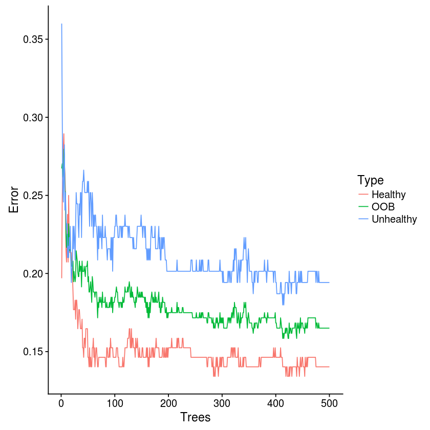

```r
ggplot(data = oob.error.data, aes(x=Trees, y=Error)) + geom_line(aes(color = Type))
```

The blue line shows the error rates while classifying **Unhealthy** patients

The green line shows the overall **OOB Error Rate**. So its in the middle (avg) of the 2

The red line shows the error rates while classifying **healthy** patients

We see in general the error rate dec when the RF has more trees

**If we added more trees would the error rate go down further?**

Lets make a RF with 1000 trees

```r
model2 <- randomForest(hd ~ ., data = data.imputed, ntree = 1000, proximity = TRUE)

model2
```

```
Call:
 randomForest(formula = hd ~ ., data = data.imputed, ntree = 1000,      proximity = TRUE)
               Type of random forest: classification
                     Number of trees: 1000
No. of variables tried at each split: 3

        OOB estimate of  error rate: 16.5%
Confusion matrix:
          Healthy Unhealthy class.error
Healthy       142        22   0.1341463
Unhealthy      28       111   0.2014388
```

OOB error rate is same as before

And confusion matrix tells us we did no better than before

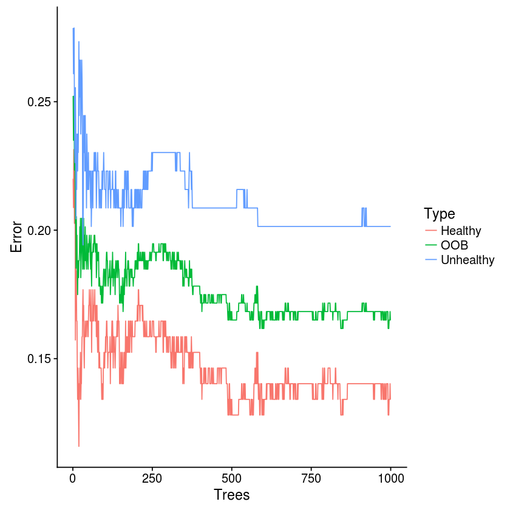

```r
Type = rep(c("OOB", "Healthy", "Unhealthy"), each = nrow(model2$err.rate))
Trees = rep(1:nrow(model2$err.rate), times = 3)
Error = c(model2$err.rate[, "OOB"],
         model2$err.rate[, "Healthy"],
         model2$err.rate[, "Unhealthy"])

oob.error.data <- data.frame(Trees = Trees, Type = Type, Error = Error)

ggplot(data = oob.error.data, aes(x=Trees, y=Error)) + geom_line(aes(color = Type))
```

The error rates stabilize right after 500 trees

So adding more trees would not help

But we would not have known this had we not added more trees

#### Optimal no of vars at each internal node

This is done using the param: mtry

```r
# Create an empty vector:

oob.values = vector(length = 10)

for (i in 1: 10){

    # build an RF using "i" to determine no of vars to try at  each step

    temp.model = randomForest(hd ~ ., data = data.imputed, mtry = i, ntree = 1000)

    # print(temp.model)

    # reqd oob value is the 1st col (OOB) of last (after building 1000) tree

    oob.value <- temp.model$err.rate[nrow(temp.model$err.rate),1]

    # Stre OOB error rate for current model

    oob.values[i] <- oob.value
}

oob.values
```

1. 0.171617161716172

2. 0.171617161716172

3. 0.161716171617162

4. 0.184818481848185

5. 0.174917491749175

6. 0.194719471947195

7. 0.181518151815182

8. 0.201320132013201

9. 0.188118811881188

10. 0.194719471947195

The 3rd value i.e no of vars = 3 is the optimal value

Coincidentally this is the default value